# The ABC of Computational Text Analysis

#3 Setting up your Development Environment

Alex Flückiger

Faculty of Humanities and Social Sciences  
University of Lucerne

07 March 2024

## Outline

- recap + discuss paper 📑
- interacting with computers 🪄
- installation of programs 🔨

## Recap last lecture

- textual data is challenging 🤯
- machine-readable data 🚧
- reproducible research using computational approach ♻️

## Reading

**Computational Social Science (Lazer et al. 2009)**

- data-driven
- network analysis + text analysis
- historical perspective vs. real-time dynamics
- issues: limited access to data and new methods

# Computers

## Two trends in computing

- everyday, mobile, cloud-centered, touch/click-based approach
  - single-purpose application
  - smartphones, smart assistants, augmented reality
- engineering, open-source, machine-oriented approach
  - powerful due to modularity
  - workflow for data science

(see also Healy 2019)

[figure not shown]

Apple Original iPhone (2007)

## Operating Systems (OS)

### Between hardware and applications

- Microsoft Windows
- macOS
- Linux-based systems 🤓

[figure not shown]

## User Interfaces (UI)

### Graphical User Interface (GUI)

[figure not shown]

### Command Line Interface (CLI)

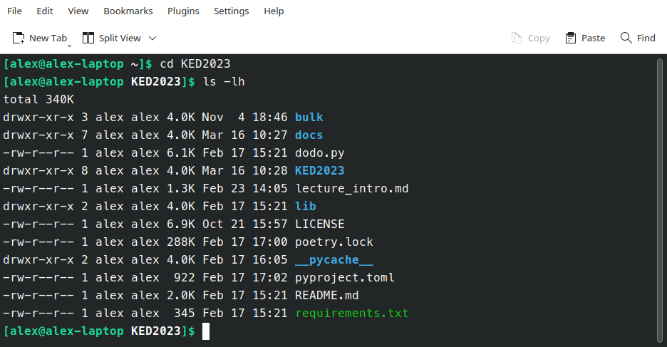

## “An awesome programmer saves the world”

## Human-Machine Interaction

### Tell the computer efficiently 🎯

- text commands instead of clicks
- similar to human languages
  - syntax (form)
  - semantics (meaning)
- computers are literalists

## Programming

- command languages
  - Bourne-Again shell (Bash), since 1989
- programming languages
  - Python, R, Java, C++ etc.
- instructions → program ≡ algorithm
  - analogous to cooking

## Package Manager 📦

### App stores for engineers

- automation of software installation
  - system: apt, Homebrew
  - Python: pip, poetry, conda
- packages have dependencies

## Open-Source is a mindset

### Standing on the shoulders of giants

- free + open software
- cross-platform portability
- collaboration
  - share + reuse
- helpful community

[figure not shown]

## Organizing data and code

- [Git](https://git-scm.com/) tracks file changes and supports version management
- [GitHub](https://github.com/) is a popular hosting platform based on Git
  - share code and collaborate
  - repository = project folder

🤓 Publishing code and data are key to open science.

## Resources everyone is using

- [Stack Overflow](https://stackoverflow.com/questions)
  - where you get answers to technical questions
- [GitHub](https://github.com/)
  - where you find open software
- [ChatGPT](https://chat.openai.com/)
  - ask anything if you get stuck

## Learning by doing, doing by Googleing + ChatGPTing. 🤸‍♀️🤸‍♂️

# Set up your System

## Backup 👹

You don’t need it until you desperately need it!

## Setting up your Development Environment

### Installation

- Python 3
  - packages for NLP + visualization
- Tesseract
- various Bash tools
- VS Code Editor

👉 Follow the [installation guide](https://aflueckiger.github.io/KED2024/materials/installation_guide.pdf) for your OS + the Python chapter.

# Relax. It takes a while.

## VS Code Editor

### The Microsoft Word for coding

- powerful integrated development environment (IDE)
- cross-platform
- interactive analysis

[figure not shown]

Write your first Python script in [VS Code](https://code.visualstudio.com/)

## First steps in Python

Learn Python with interactive tutorials

- [Python Principles](https://pythonprinciples.com)
- [LearnPython](https://www.learnpython.org/en/Welcome)

## Readings

### Optional: pimp your workflow

Healy, Kieran. 2019. “The Plain Person’s Guide to Plain Text Social Science.” [online](https://kieranhealy.org/publications/plain-person-text/).

# Questions?

## References

Healy, Kieran. 2019. “The Plain Person’s Guide to Plain Text Social Science.” https://kieranhealy.org/publications/plain-person-text/.

Lazer, David, Alex Pentland, Lada Adamic, Sinan Aral, Albert-László Barabási, Devon Brewer, Nicholas Christakis, et al. 2009. “Computational Social Science.” *Science* 323 (5915): 721–23. https://doi.org/10.1126/science.1167742.